# O que os dados fiscais dos municípios brasileiros contam a respeito de sua dependência de transferências

## Introdução

### Apresentação

O que apresentaremos a seguir é um exercício de exploração de dados relativamente superficial, porém com uma razoável variedade de visualizações.

Os dados principais foram obtidos do Siconfi, sob gestão da STN/CCONF. São dados que contemplam receitas e despesas da maioria dos municípios brasileiros, para o exercício de 2015. Esses dados estão disponíveis em [página do site da Secretaria do Tesouro Nacional](http://www.tesouro.gov.br/web/stn/balanco-do-setor-publico-nacional-bspn-).

Além disso, esses dados foram combinados com [dados](https://www.ibge.gov.br/estatisticas-novoportal/downloads-estatisticas.html) do IBGE relativos ao PIB dos municípios, bem como [dados geográficos desse instituto](https://www.ibge.gov.br/geociencias-novoportal/downloads-geociencias.html) que permitiram o desenvolvimento de visualizações na forma de mapas, e dados da [arrecadação federal](http://idg.receita.fazenda.gov.br/dados/receitadata/arrecadacao/arrecadacao-das-receitas-administradas-pela-rfb-por-municipio) divulgados pela Receita Federal.

### Definindo “dependência financeira de transferências”

O [Boletim de Finanças dos Entes Subnacionais de 2017](https://www.tesouro.fazenda.gov.br/pt/-/boletim-de-financas-dos-entes-subnacionais-2017) define os conceitos de *receitas de arrecadação própria* e *receitas de transferência* da seguinte forma:

**Receita de Arrecadação Própria**

Montante da receita correspondente ao somatório das receitas tributárias (exceto o Imposto de Renda Retido na Fonte incidente sobre valores pagos pelo Estado), de contribuições, patrimoniais (exceto as financeiras), agropecuárias, industriais, de serviços (exceto as financeiras), outras receitas correntes, amortizações de empréstimos e outras receitas de capital.

**Receitas de Transferências**

Montante das receitas de transferências correntes, de capital e do Imposto de Renda Retido na Fonte incidente sobre valores pagos pelo Estado.

Neste nosso estudo, utilizamos essencialmente essas duas variáveis, além da *receita total*. Por simplicidade, consideramos *receitas de transferências* todas as rubricas que se referem a receitas de transfêrencias, e obtivemos as *receitas prórias* pela diferença a partir da *receita total*.

### Uma hipótese inicial

Uma crença hipótese recorrente é a de que os municípios das regiões norte e nordeste seriam os mais dependentes de transferências <sup>[*citation needed*]</sup>.

### Preparação dos dados

Iniciamos a análise carregando as bibliotecas necessárias para a preparação dos dados.

```r
library(readxl)
library(tidyverse)
```

A base principal de dados está disponível num arquivo em formato Excel (e, em breve, disponível no [Tesouro Transparente](https://www.tesourotransparente.gov.br/).)

Nesse arquivo, temos planilhas com informações de receitas, despesas e transferências. Vamos carregar os dados.

```r
# Pendências: UF diferente, numa tá sigla, na outra tá o nome

# setwd("C:/Users/tiago.pereira/OneDrive - Secretaria do Tesouro Nacional/GT-CEAD/projs/EeM")

# dados da dependência
painel <- read_excel("dados/Indicadores Municipais - Parte 2.xlsx", sheet="Dependencia de transferencias", range = cell_limits(c(8, 2), c(NA, 13)))

painel <- painel %>%
  mutate(Municipio = as.factor(`Ente da Federação`),
         Regiao = as.factor(`Região`),
         UF = as.factor(UF),
         CatPop = as.factor(`Categoria População`),
         TransfCor = `1.7.0.0.00.00.00 - Transferências Correntes`,
         TransfCap = `2.0.0.0.00.00.00 - Receitas de Capital`,
         TransfTot = `Total de Transferências`,
         RecCor = `1.0.0.0.00.00.00 - Receitas Correntes`,
         RecCap = `2.0.0.0.00.00.00 - Receitas de Capital`,
         RecTot = `Total Receitas Orçamentárias`,
         RecProp = RecTot - TransfTot,
         GrauDep = `Grau de Dependência`
         ) %>%
  select(Municipio,Regiao,UF,CatPop,TransfCor,TransfCap,TransfTot,RecCor,RecCap,RecTot,RecProp,GrauDep)

# dados das receitas
rec2015 <- read_excel("dados/Indicadores Municipais - Parte 2.xlsx", sheet="Base I-C-Receitas Orçamentarias", range = cell_rows(c(5, NA)))

# armazenar a lista de contas (naturezas de receita) só para futura referência, caso queiramos acrescentar algo
contasRec <- levels(as.factor(rec2015$Conta))

# transformações e seleção do que nos interessa, que é a receita de IPTU.
rec2015 <- rec2015 %>%
  filter(Origem == "Receita Bruta") %>%
  spread(key=Conta,value=Valor) %>%
  mutate(IPTU = `1.1.1.2.02.00.00 - Imposto sobre a Propriedade Predial e Territorial Urbana ¿ IPTU`
              + `1.9.1.1.38.00.00 - Multas e Juros de Mora do Imposto sobre a Propriedade Predial e Territorial Urbana ¿ IPTU`
              + `1.9.1.3.11.00.00 - Multas e Juros de Mora da Dívida Ativa do Imposto sobre a Propriedade Predial e Territorial Urbana ¿ IPTU`
              + `1.9.3.1.11.00.00 - Receita da Dívida Ativa do Imposto sobre a Propriedade Predial e Territorial Urbana ¿ IPTU`,
         Municipio = as.factor(`Instituição`),
         IBGE = as.factor(Cod.IBGE),
         SiglaUF = as.factor(UF)
         ) %>%
  select(Municipio, IBGE, UF, IPTU)

# dados das despesas
desp2015 <- read_excel("dados/Indicadores Municipais - Parte 2.xlsx", sheet="Despesas por função", range = cell_limits(c(8, 2), c(NA, 34)))

# incluindo uma coluna de total! é o rowSums, e não o colSums. Não conhecia essa notação do "." tb.
desp2015 <- desp2015 %>%
  replace(is.na(.), 0) %>%
  mutate(DespTotal = rowSums(.[,6:33]),
         Municipio = as.factor(`Ente da Federação`),
         Regiao = as.factor(`Região`),
         SiglaUF = as.factor(UF),
         CatPop = as.factor(`Categoria População`),
         DespEduc = `12 - Educação`,
         DespSaude = `10 - Saúde`) %>%
  select(Municipio, Regiao, SiglaUF, CatPop, DespEduc, DespSaude, DespTotal)

# juntando todos
painel <- merge(painel, rec2015)
painel <- merge(painel, desp2015)

# reordenando os fatores para manter a padronização das cores mais na frente
painel$Regiao <- factor(painel$Regiao, levels=c("Sul", "Sudeste","Centro-Oeste", "Nordeste", "Norte"))
```

O grau de dependência é definido como a razão entre a *Receita de Transferências* e a *Receita Total*. Podemos definir faixas de dependência, como, por exemplo, “até 50%”, “entre 50 e 80%”, “entre 80 e 90%” e “mais de 90%”. A contagem de municípios nessas faixas é a seguinte:

```r
painel$CatDep <- cut(painel$GrauDep, breaks = c(0,0.5,0.8,0.9,1), labels = c("até 50%","entre 50 e 80%","entre 80 e 90%", "mais de 90%"))
summary(painel$CatDep)
```

```
##        até 50% entre 50 e 80% entre 80 e 90%    mais de 90%           NA's
##             56           1147           1628           2170             12
```

Assim, os dados disponíveis no *dataframe* `painel` formam a nossa base principal, com a seguinte estrutura, por enquanto:

```r
head(painel)
```

|  | Municipio | Regiao | CatPop | UF | TransfCor | TransfCap | TransfTot | RecCor | RecCap | RecTot | RecProp | GrauDep | IBGE | IPTU | SiglaUF | DespEduc | DespSaude | DespTotal | CatDep |
| --- | --- | --- | --- | --- | --- | --- | --- | --- | --- | --- | --- | --- | --- | --- | --- | --- | --- | --- | --- |
| 1 | Abadia de Goiás - GO | Centro-Oeste | menos de 50k | GO | 19094252 | 1988959.9 | 19759012 | 25403707 | 1988959.9 | 27392667 | 7633655 | 0.7213249 | 5200050 | NA | GO | 9561831 | 4916546 | 26776994 | entre 50 e 80% |
| 2 | Abadia dos Dourados - MG | Sudeste | menos de 50k | MG | 14307562 | 906164.6 | 15138406 | 15694014 | 906164.6 | 16600179 | 1461773 | 0.9119423 | 3100104 | 117184.3 | MG | 5052802 | 3966135 | 16378371 | mais de 90% |
| 3 | Abadiânia - GO | Centro-Oeste | menos de 50k | GO | 21394831 | 0.0 | 21394831 | 29538591 | 0.0 | 29538591 | 8143761 | 0.7243010 | 5200100 | NA | GO | 8133625 | 6793579 | 33101011 | entre 50 e 80% |
| 4 | Abaeté - MG | Sudeste | menos de 50k | MG | 29878741 | 2665452.2 | 32544193 | 34841270 | 2665452.2 | 37506722 | 4962529 | 0.8676896 | 3100203 | NA | MG | 10282892 | 12679544 | 36669591 | entre 80 e 90% |
| 5 | Abaetetuba - PA | Norte | entre 50 e 500k | PA | 186137395 | 3348378.6 | 189485774 | 200268362 | 3348378.6 | 203616740 | 14130966 | 0.9306002 | 1500107 | NA | PA | 98127307 | 47060044 | 216301213 | mais de 90% |
| 6 | Abaíra - BA | Nordeste | menos de 50k | BA | 14329544 | 1677777.2 | 15168433 | 15250377 | 1677777.2 | 16928154 | 1759721 | 0.8960477 | 2900108 | NA | BA | 4625667 | 3378149 | 15814190 | entre 80 e 90% |

Em seguida, vamos incluir informações adicionais dos municípios, a partir de outras bases de dados:

- PIB dos Municípios, do IBGE (“PIB_Municipios”, disponível em disponível em https://downloads.ibge.gov.br/downloads_estatisticas.htm); e
- Arrecadação federal nos municípios, da Receita Federal (http://idg.receita.fazenda.gov.br/dados/receitadata/arrecadacao/arrecadacao-das-receitas-administradas-pela-rfb-por-municipio).

```r
pibMun <- read_excel("dados/PIB dos Municípios - base de dados 2010-2015.xls") %>% filter(Ano == "2015")

# ajustando os dados
pibMun <- pibMun %>%
  mutate(UF = as.factor(`Nome da Unidade da Federação`),
         IBGE = as.factor(`Código do Município`),
         MunicipioSemUF = as.factor(`Nome do Município`),
         pib = `Produto Interno Bruto, a preços correntes
(R$ 1.000)`,
         pibPerCapita = `Produto Interno Bruto per capita
(R$ 1,00)`,
         pop = `População
(Nº de habitantes)`,
         atividadePrincipal = as.factor(`Atividade com maior valor adicionado bruto`)
         ) %>%
  select(IBGE,UF,MunicipioSemUF,pib,pibPerCapita,pop,atividadePrincipal)

# lista de municípios fora da base do Siconfi
municipios_excluidos <- anti_join(pibMun,painel, by = "IBGE")
sum(municipios_excluidos$pop)
```

```
## [1] 16634998
```

```r
# incorporando os dados do IBGE à base
painel <- merge(painel, pibMun, by = "IBGE")
```

```r
# carga do arquivo
arrecFedMun <- read_excel("dados/ARRECADAÇÃO DA RECEITA ADMINISTRADA PELA RFB POR MUNICÍPIO - 2004 A 2017.xlsx", sheet="Recolhimentos em DARF", range = cell_limits(c(6, 1), c(NA, 15)))

# captura dos dados que interessam
arrecFedMun <- arrecFedMun %>%
  mutate(Municipio = as.factor(`MUNICÍPIOS`),
         arrecFed = `2015`
         ) %>%
  select(Municipio, arrecFed)

# registro dos municipios que estão no Painel, mas não no arquivo da receita
municipios_fora_arq_rec <- anti_join(painel, arrecFedMun, by = "Municipio")
sum(municipios_fora_arq_rec$pop)
```

```
## [1] 1170927
```

```r
# incorporação da informação da arrecadação federal no painel.
# usando left_join para manter os municipios que estão fora do arquivo da receita.
painel <- painel %>%
  left_join(arrecFedMun, by = "Municipio")
```

Vamos construir alguns gráficos baseados em informações geográficas, colorindo o mapa do Brasil município a município, conforme os valores da variável em análise.

```r
# refiz a construção da base geográfica para pegar apenas informações da população.
# na base do Siconfi faltam muitos municípios, ficam muitos "buracos" no mapa.
# como só pretendo usar o mapa para demonstrar a distribuição da população

library(rgeos)
library(maptools)
library(rgdal)
library(RColorBrewer)

# preparação da variável que será plotada
mapaCatPop <- pibMun[,c(1,2,6)]
ufs <- levels(pibMun$UF)
regioes <- c("Norte","Nordeste","Norte","Norte","Nordeste","Nordeste","Centro-Oeste","Sudeste","Centro-Oeste","Nordeste","Centro-Oeste","Centro-Oeste","Sudeste","Norte","Nordeste","Sul","Nordeste","Nordeste","Sudeste","Nordeste","Sul","Norte","Norte","Sul","Sudeste","Nordeste","Norte")
ufXreg <- data.frame(ufs,regioes)
mapaCatPop <- merge(mapaCatPop, ufXreg, by.x="UF", by.y="ufs")
mapaCatPop$pop <- cut(mapaCatPop$pop, breaks = c(0,50000,500000,Inf), labels = c("menos de 50 mil","entre 50 e 500 mil","mais que 500 mil"))

# abrindo o arquivo SDP do IBGE
# https://mapas.ibge.gov.br/bases-e-referenciais/bases-cartograficas/malhas-digitais.html
mapaBR <- readOGR(dsn="maps", layer="BRMUE250GC_SIR")
mapaBR$CD_GEOCODM = as.factor(mapaBR$CD_GEOCMU)
#pq nao é com @data?

## Juntar ao mapa os dados a serem plotados
# o exemplo:
# rj <- merge(rj, base.media, by.x='CD_GEOCODM', by.y='ibge')

# no nosso caso, já criei uma variável nova no mapaBR chamada IBGE,
# com o mesmo nome da variável na base de dados.
# então não preciso do by.x e by.y, só o by.

#mapaBR <- merge(mapaBR, painel, by.x='CD_GEOCODM', by.y='IBGE')

# vou usar o dataframe que criei, mais enxuto (e ao mesmo tempo mais completo, já que
# contempla todos os municípios), e não mais o "painel".

mapaBR <- merge(mapaBR, mapaCatPop, by.x='CD_GEOCODM', by.y='IBGE')

# [comentário do original:]
# http://rstudio-pubs-static.s3.amazonaws.com/24563_3b7b0a6414824e3b91769a95309380f1.html
# Para usarmos o ggplot2 para plotar os dados no gráfico,
# será necessário extrair da base geoferenciada um data frame
# com as informações a serem plotadas.
# Para fazer esta extração utiliza-se a função fortify() do pacote ggplot2.

# Extrai um data frame com coordenadas - variáveis: long  lat  order  hole  piece  group  id
# gpclibPermitStatus(TRUE)

mapaBR.df <- fortify(mapaBR, region = "CD_GEOCODM")

# tava dando um erro no fortify do ggplot, aí reinstalei os pacotes, começando pelo rgeos.

#install.packages('rgeos', type='source')
#install.packages('maptools')
#install.packages('rgdal', type='source')

mapaBR.df <- merge(mapaBR.df, mapaBR@data, by.x = "id", by.y = "CD_GEOCODM")

#mapaBR.df$indDepCat <- cut(mapaBR.df$indDep, breaks = c(0, 0.25, 0.5, 0.6, 0.7, 0.8, 0.9, 1.0),
#                         labels=c('0-25%', '25-50%', '50-60%', '60-70%', '70-80%', '80-90%', '90-100%'),
#                         include.lowest=TRUE)
```

Vamos então carregar fontes, preparar rótulos, preparar o tema dos gráficos.

```r
library(extrafont)
font_import()
```

```
## Importing fonts may take a few minutes, depending on the number of fonts and the speed of the system.
## Continue? [y/n]
```

```r
loadfonts(device = "win")

# para mostrar os rótulos numa notação mais bonitinha
fancy_scientific <- function(l) {
  # turn in to character string in scientific notation
  l <- format(l, scientific = TRUE)
  # quote the part before the exponent to keep all the digits
  l <- gsub("^(.*)e", "'\\1'e", l)
  # turn the 'e+' into plotmath format
  l <- gsub("e", "%*%10^", l) # original era: l <- gsub("e", "%*%10^", l)
  # return this as an expression
  parse(text=l)
}

## definindo o nosso tema
theme_GTCEAD <- function(){
  theme_minimal() +
  theme(
    text = element_text(family = "Roboto Condensed Light"), #Cambria? #"Source Sans Pro"
    title = element_text(colour = "gray25", face = "bold", family = "Roboto Condensed"),
    plot.subtitle = element_text(face = "plain"),
    plot.caption = element_text(colour = "gray30", face = "plain"),
    strip.background = element_rect(fill = "gray60", color = "gray95")
  )
}

tresCores <- c("#028063", "#4E857E", "#1E466A") #c("#D5845E","#F3987D","#FECE60")
```

## Análise

### Analisando o perfil dos municípios brasileiros

Nossa base de dados divide os municípios em três categorias, conforme a população:

- Municípios com até 50 mil habitantes;
- Municípios com população entre 50 mil e 500 mil habitantes; e
- Municípios com mais de 500 mil habitantes.

Assim, inicialmente, vamos ver como algumas quantidades se distribuem entre essas três categorias. Vamos começar com uma visualização da distribuição geográfica entre essas três categorias, com base nos territórios de cada município no mapa do Brasil.

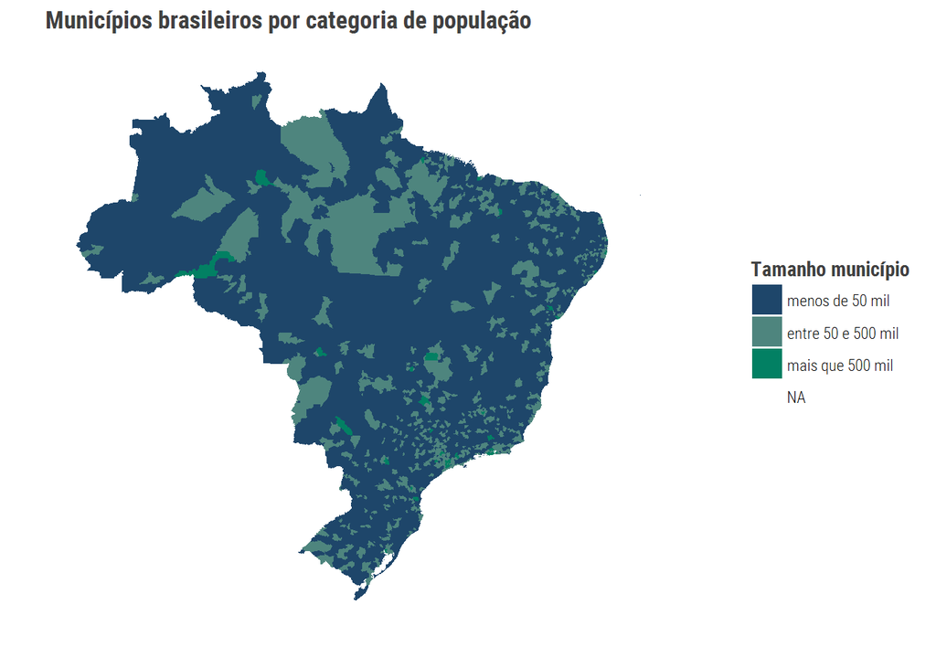

```r
plotMapaDist <- ggplot(mapaBR.df, aes(long, lat, group = group, fill = pop)) +
  geom_polygon(colour=NA)  +
  coord_equal() +
  ggtitle('Municípios brasileiros por categoria de população') +
  #theme(plot.title=element_text(size=rel(1), lineheight=.9, face="bold", colour="blue")) +
  labs(x = "", y = "", fill = "Tamanho município")+
  scale_fill_manual(values=rev(tresCores))#brewer.pal(9, 'Greens')[3:9])


plotMapaDist + theme_GTCEAD() +
  theme(
    panel.grid.major = element_blank(),
    panel.grid.minor = element_blank(),
    axis.text = element_blank())
```

Como então se distribuem a quantidade de municípios, a população, o PIB e a arrecadação federal nessas categorias?

Vamos sumarizar nossos dados.

```r
# aprendi uma penca de coisas aqui

sumario <- painel %>%
  mutate(conta=as.numeric(as.character(Municipio))) %>%
  group_by(CatPop) %>%
  summarize(
    Qde = sum(is.na(conta)),
    Pop=sum(pop),
    Pib=sum(pib),
    recFed = sum(arrecFed,na.rm=TRUE),
    recIPTU = sum(IPTU,na.rm=TRUE),
    despEduc = sum(DespEduc),
    despSaud = sum(DespSaude)
    )%>%
  select(CatPop,Qde,Pop,Pib,recFed,recIPTU,despEduc,despSaud) %>%
  gather(Qde,Pop,Pib,recFed,recIPTU,despEduc,despSaud, key="Variavel", value="Valor")

# calculando população total para usar na posição da linha vertical
pop <- sumario[sumario$Variavel=="Pop",][,3]
total_pop<-sum(pop)

# definindo a ordem dos fatores da legenda e das categorias (em ordem inversa, go figure)
# primeiro renomeando as categorias, para tirar os "k"
levels(sumario$CatPop) <- c("entre 50 e 500 mil", "mais que 500 mil", "menos de 50 mil")
# agora sim, redefinindo a ordem dos níveis, para que no gráfico apareça do jeito que quero
sumario$CatPop <- factor(sumario$CatPop, levels = rev(c("menos de 50 mil","entre 50 e 500 mil","mais que 500 mil")))

sumario$Variavel <- factor((sumario$Variavel), levels = rev(c("Pop","Qde","Pib","recFed", "recIPTU", "despEduc", "despSaud")))
```

#### A distribuição das variáveis conforme as categorias de população

Plotando os dados…

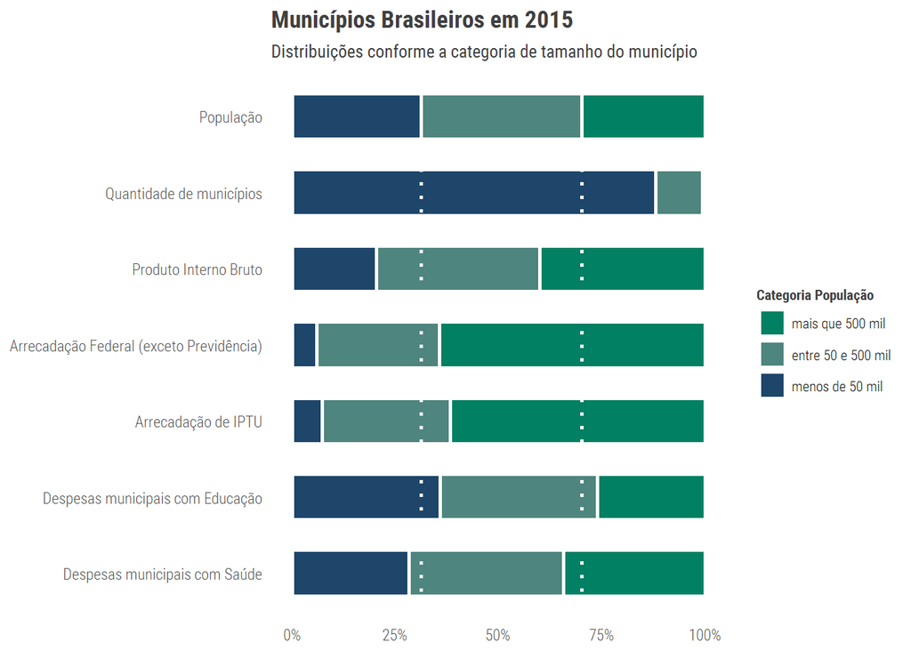

```r
plotSumario <- ggplot(sumario, aes(fill=CatPop, y=Valor, x=Variavel)) +
    coord_flip() +
    geom_bar( stat="identity", position="fill", width=0.6, color = "white", size = 1) +
    labs(
      x = NULL,
      y = NULL,
      fill = "Categoria População",
      title = "Municípios Brasileiros em 2015",
      subtitle = "Distribuições conforme a categoria de tamanho do município"
    ) +
    scale_x_discrete(labels=c("Qde" = "Quantidade de municípios",
                              "Pop" = "População",
                              "Pib" = "Produto Interno Bruto",
                              "recFed" = "Arrecadação Federal (exceto Previdência)",
                              "recIPTU" = "Arrecadação de IPTU",
                              "despEduc" = "Despesas municipais com Educação",
                              "despSaud" = "Despesas municipais com Saúde")) +
    scale_y_continuous(labels = scales::percent) +
    scale_fill_manual(values = tresCores)+#c("#D5845E","#F3987D","#FECE60")) +
    geom_hline(yintercept = (sumario$Valor[which(sumario$CatPop == "menos de 50 mil" & sumario$Variavel=="Pop")])/total_pop, color = "white", linetype="dotted", size = 1) +
    geom_hline(yintercept = 1 - (sumario$Valor[which(sumario$CatPop == "mais que 500 mil" & sumario$Variavel=="Pop")])/total_pop, color = "white", linetype="dotted", size = 1) +
    #geom_text(aes(label=Valor, x=Variavel, stat="identity"), position=position_stack(), check_overlap = FALSE, size = 2)+

    # annotate(geom="text",
    #          x=2.6,
    #          y=0,
    #          label=paste(format(round((100*sumario$Valor[which(sumario$`Categoria População`=="menos de 50k" & sumario$Variavel=="Pop")])/total_pop,2),nsmall=2,decimal.mark=","),"%"),
    #          color = "grey50", # tirar daqui e levar para theme
    #          size = 2,
    #          hjust=0) +
    #
    # annotate(geom="text",
    #          x=2.7,
    #          y=0,
    #          label=paste(format(sumario$Valor[which(sumario$`Categoria População`=="menos de 50k" & sumario$Variavel=="Pop")], nsmall=0, big.mark=".", decimal.mark=","), "milhões"),
    #          color = "grey50",
    #          size = 2,
    #          hjust=0) +
    # annotate(geom="text",
    #          x = 7.5,
    #          y=(sumario$Valor[which(sumario$CatPop == levels(sumario$CatPop)[1] & sumario$Variavel=="Pop")])/2*total_pop,
    #          label = levels(sumario$CatPop)[1],
    #          size = 2,
    #          color = tresCores[1]
    #          )+

# quando incluo algum desses geom text, às vezes as barras somem. estudar melhor.

    theme_GTCEAD() +
    theme(
      panel.grid.major = element_blank(),
      panel.grid.minor = element_blank(),
      legend.text = element_text(size = 8),
      legend.title = element_text(size = 8))

plotSumario
```

#### A distribuição por regiões…

```r
# aprendi uma penca de coisas aqui

sumario_reg <- painel %>%
  mutate(conta=as.numeric(as.character(Municipio))) %>%
  group_by(CatPop,Regiao) %>%
  summarize(
    Qde = sum(is.na(conta)),
    Pop = sum(pop),
    Pib = sum(pib),
    recFed = sum(arrecFed,na.rm=TRUE),
    recIPTU = sum(IPTU,na.rm=TRUE),
    despEduc = sum(DespEduc),
    despSaud = sum(DespSaude)
    )%>%
  select(CatPop,Regiao,despSaud,despEduc,recIPTU,recFed,Pib,Qde,Pop)

# definindo a ordem dos fatores da legenda e das categorias (em ordem inversa, go figure)
# primeiro renomeando as categorias, para tirar os "k"
levels(sumario_reg$CatPop) <- c("entre 50 e 500 mil", "mais que 500 mil", "menos de 50 mil")
# agora sim, redefinindo a ordem dos níveis, para que no gráfico apareça do jeito que quero
sumario_reg$CatPop <- factor(sumario_reg$CatPop, levels = rev(c("menos de 50 mil","entre 50 e 500 mil","mais que 500 mil")))

# preciso acrescentar o "Brasil" como região, para a comparação. vou aproveitar o "sumario",
# que não está quebrado por região. vou só fazer um spread.
sumario_reg_total <- sumario %>%
  mutate(Regiao = "Brasil") %>%
  spread(key = rev("Variavel"), value = "Valor")

# acrescentando esses totais "Brasil" ao sumário...
# não dá para usar rbind! pq são tibbles, tem q usar o bind_rows do dplyr
sumario_reg <- bind_rows(sumario_reg, sumario_reg_total)

sumario_reg$Regiao <- as.factor(sumario_reg$Regiao)
sumario_reg$Regiao <- factor(sumario_reg$Regiao, levels = rev(levels(sumario_reg$Regiao)))

# calculando um vetor com os totais (equivalente ao "Brasil")
# para usar nas posições das linhas verticais

totais <- subset(sumario_reg, sumario_reg$Regiao=="Brasil")
totais <- totais[,3:9]
totais_v <- colSums(totais)
names(totais_v) <- names(totais)

sumario_tot <- sumario_reg %>%
  filter(Regiao != "Brasil") %>%
  group_by(Regiao) %>%
  summarise(Pop = sum(Pop),
            Qde = sum(Qde),
            despSaud = sum(despSaud),
            despEduc = sum(despEduc),
            recIPTU = sum(recIPTU),
            recFed = sum(recFed),
            Pib = sum(Pib))

sumario_tot_gathered <- sumario_tot %>%
  gather(Qde,Pop,Pib,recFed,recIPTU,despEduc,despSaud, key="Variavel", value="Valor")

sumario_tot_gathered$Variavel <- factor(sumario_tot_gathered$Variavel, levels= rev(c("Pop","Qde","Pib","recFed","recIPTU","despEduc","despSaud")))

# Definindo a ordem das regiões no preenchimento das barras...
levels(sumario_tot_gathered$Regiao) <- c("Sul","Sudeste","Centro-Oeste","Nordeste","Norte","Brasil")
```

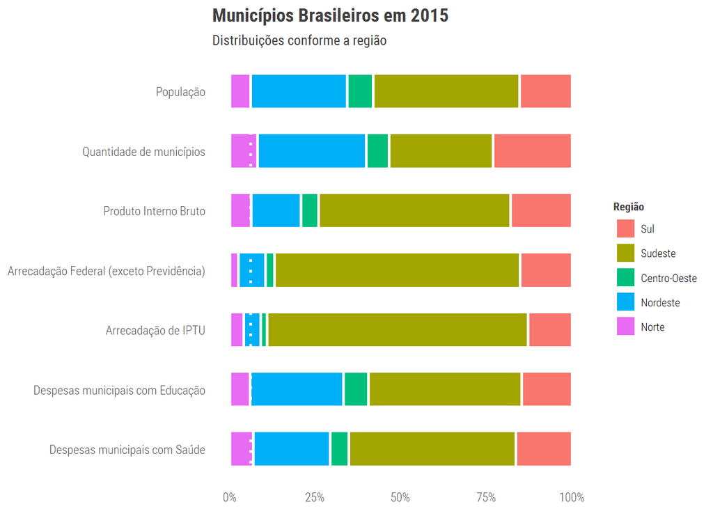

```r
plotSumario_Regional <- ggplot(sumario_tot_gathered, aes(fill=Regiao, y=Valor, x=Variavel)) +
    coord_flip() +
    geom_bar( stat="identity", position="fill", width=0.6, color = "white", size = 1) +
    labs(
      x = NULL,
      y = NULL,
      fill = "Região",
      title = "Municípios Brasileiros em 2015",
      subtitle = "Distribuições conforme a região"
    ) +
    scale_x_discrete(labels=c("Qde" = "Quantidade de municípios",
                              "Pop" = "População",
                              "Pib" = "Produto Interno Bruto",
                              "recFed" = "Arrecadação Federal (exceto Previdência)",
                              "recIPTU" = "Arrecadação de IPTU",
                              "despEduc" = "Despesas municipais com Educação",
                              "despSaud" = "Despesas municipais com Saúde")) +
    scale_y_continuous(labels = scales::percent) +
    #scale_fill_manual(values = tresCores)+
    geom_hline(yintercept = (sumario_tot$Pop[which(sumario_tot$Regiao == "Centro-Oeste")])/sum(sumario_tot$Pop), color = "white", linetype="dotted", size = 1) +
    theme_GTCEAD() +
    theme(
      panel.grid.major = element_blank(),
      panel.grid.minor = element_blank(),
      legend.text = element_text(size = 8),
      legend.title = element_text(size = 8))

plotSumario_Regional
```

#### A distribuição das variáveis conforme as categorias de população e regiões

Nos próximos gráficos, nossa intenção é explorar como cada uma dessas variáveis se distribuem entre os conjuntos de municípios “Pequenos”, “Médios” e “Grandes” em cada uma das diferentes regiões do Brasil.

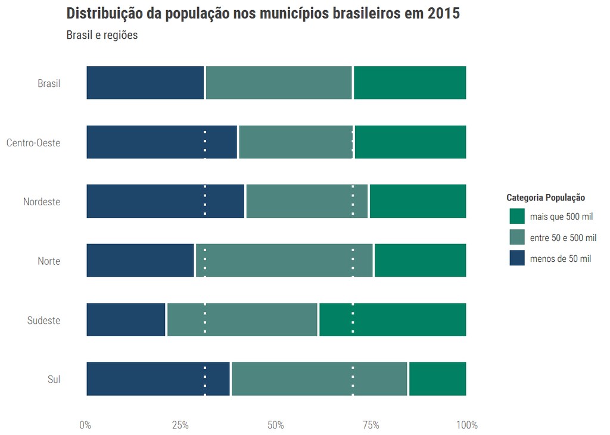

```r
# forma bizantina de se fazer.
# como eu poderia criar uma função que passasse a variável a ser usada em:
# aes(y = <variavel>) e
# totais_v["<variavel>"]?

plotSumario_reg_pop <- ggplot(sumario_reg, aes(fill = CatPop, y = Pop, x = Regiao)) +
    coord_flip() +
    geom_bar( stat="identity", position="fill", width=0.6, color = "white", size = 1) +
    labs(
      x = NULL,
      y = NULL,
      fill = "Categoria População",
      title = "Distribuição da população nos municípios brasileiros em 2015",
      subtitle = "Brasil e regiões"
    ) +
    #scale_x_discrete(labels=rev(levels(sumario_reg$Regiao))) +
    scale_y_continuous(labels = scales::percent) +
    scale_fill_manual(values = tresCores)+#c("#D5845E","#F3987D","#FECE60")) +
    geom_hline(yintercept = (sumario_reg$Pop[which(sumario_reg$CatPop == "menos de 50 mil" & sumario_reg$Regiao=="Brasil")])/totais_v["Pop"], color = "white", linetype="dotted", size = 1) +
    geom_hline(yintercept = 1 - (sumario_reg$Pop[which(sumario_reg$CatPop == "mais que 500 mil" & sumario_reg$Regiao=="Brasil")])/totais_v["Pop"], color = "white", linetype="dotted", size = 1) +
    theme_GTCEAD() +
    theme(
      panel.grid.major = element_blank(),
      panel.grid.minor = element_blank(),
      legend.text = element_text(size = 8),
      legend.title = element_text(size = 8))

plotSumario_reg_qde <- ggplot(sumario_reg, aes(fill = CatPop, y = Qde, x = Regiao)) +
    coord_flip() +
    geom_bar( stat="identity", position="fill", width=0.6, color = "white", size = 1) +
    labs(
      x = NULL,
      y = NULL,
      fill = "Categoria População",
      title = "Distribuição da quantidade de municípios brasileiros em 2015",
      subtitle = "Brasil e regiões"
    ) +
    #scale_x_discrete(labels=rev(levels(sumario_reg$Regiao))) +
    scale_y_continuous(labels = scales::percent) +
    scale_fill_manual(values = tresCores)+#c("#D5845E","#F3987D","#FECE60")) +
    geom_hline(yintercept = (sumario_reg$Qde[which(sumario_reg$CatPop == "menos de 50 mil" & sumario_reg$Regiao=="Brasil")])/totais_v["Qde"], color = "white", linetype="dotted", size = 1) +
    geom_hline(yintercept = 1 - (sumario_reg$Qde[which(sumario_reg$CatPop == "mais que 500 mil" & sumario_reg$Regiao=="Brasil")])/totais_v["Qde"], color = "white", linetype="dotted", size = 1) +
    theme_GTCEAD() +
    theme(
      panel.grid.major = element_blank(),
      panel.grid.minor = element_blank(),
      legend.text = element_text(size = 8),
      legend.title = element_text(size = 8))

plotSumario_reg_pib <- ggplot(sumario_reg, aes(fill = CatPop, y = Pib, x = Regiao)) +
    coord_flip() +
    geom_bar( stat="identity", position="fill", width=0.6, color = "white", size = 1) +
    labs(
      x = NULL,
      y = NULL,
      fill = "Categoria População",
      title = "Distribuição do PIB dos municípios brasileiros em 2015",
      subtitle = "Brasil e regiões"
    ) +
    #scale_x_discrete(labels=rev(levels(sumario_reg$Regiao))) +
    scale_y_continuous(labels = scales::percent) +
    scale_fill_manual(values = tresCores)+#c("#D5845E","#F3987D","#FECE60")) +
    geom_hline(yintercept = (sumario_reg$Pib[which(sumario_reg$CatPop == "menos de 50 mil" & sumario_reg$Regiao=="Brasil")])/totais_v["Pib"], color = "white", linetype="dotted", size = 1) +
    geom_hline(yintercept = 1 - (sumario_reg$Pib[which(sumario_reg$CatPop == "mais que 500 mil" & sumario_reg$Regiao=="Brasil")])/totais_v["Pib"], color = "white", linetype="dotted", size = 1) +
    theme_GTCEAD() +
    theme(
      panel.grid.major = element_blank(),
      panel.grid.minor = element_blank(),
      legend.text = element_text(size = 8),
      legend.title = element_text(size = 8))

plotSumario_reg_recFed <- ggplot(sumario_reg, aes(fill = CatPop, y = recFed, x = Regiao)) +
    coord_flip() +
    geom_bar( stat="identity", position="fill", width=0.6, color = "white", size = 1) +
    labs(
      x = NULL,
      y = NULL,
      fill = "Categoria População",
      title = "Distribuição da arrecadação federal nos municípios brasileiros em 2015",
      subtitle = "Brasil e regiões"
    ) +
    #scale_x_discrete(labels=rev(levels(sumario_reg$Regiao))) +
    scale_y_continuous(labels = scales::percent) +
    scale_fill_manual(values = tresCores)+#c("#D5845E","#F3987D","#FECE60")) +
    geom_hline(yintercept = (sumario_reg$recFed[which(sumario_reg$CatPop == "menos de 50 mil" & sumario_reg$Regiao=="Brasil")])/totais_v["recFed"], color = "white", linetype="dotted", size = 1) +
    geom_hline(yintercept = 1 - (sumario_reg$recFed[which(sumario_reg$CatPop == "mais que 500 mil" & sumario_reg$Regiao=="Brasil")])/totais_v["recFed"], color = "white", linetype="dotted", size = 1) +
    theme_GTCEAD() +
    theme(
      panel.grid.major = element_blank(),
      panel.grid.minor = element_blank(),
      legend.text = element_text(size = 8),
      legend.title = element_text(size = 8))

plotSumario_reg_recFed <- ggplot(sumario_reg, aes(fill = CatPop, y = recFed, x = Regiao)) +
    coord_flip() +
    geom_bar( stat="identity", position="fill", width=0.6, color = "white", size = 1) +
    labs(
      x = NULL,
      y = NULL,
      fill = "Categoria População",
      title = "Distribuição da arrecadação federal nos municípios brasileiros em 2015",
      subtitle = "Brasil e regiões"
    ) +
    #scale_x_discrete(labels=rev(levels(sumario_reg$Regiao))) +
    scale_y_continuous(labels = scales::percent) +
    scale_fill_manual(values = tresCores)+#c("#D5845E","#F3987D","#FECE60")) +
    geom_hline(yintercept = (sumario_reg$recFed[which(sumario_reg$CatPop == "menos de 50 mil" & sumario_reg$Regiao=="Brasil")])/totais_v["recFed"], color = "white", linetype="dotted", size = 1) +
    geom_hline(yintercept = 1 - (sumario_reg$recFed[which(sumario_reg$CatPop == "mais que 500 mil" & sumario_reg$Regiao=="Brasil")])/totais_v["recFed"], color = "white", linetype="dotted", size = 1) +
    theme_GTCEAD() +
    theme(
      panel.grid.major = element_blank(),
      panel.grid.minor = element_blank(),
      legend.text = element_text(size = 8),
      legend.title = element_text(size = 8))

plotSumario_reg_recIPTU <- ggplot(sumario_reg, aes(fill = CatPop, y = recIPTU, x = Regiao)) +
    coord_flip() +
    geom_bar( stat="identity", position="fill", width=0.6, color = "white", size = 1) +
    labs(
      x = NULL,
      y = NULL,
      fill = "Categoria População",
      title = "Distribuição da arrecadação de IPTU nos municípios brasileiros em 2015",
      subtitle = "Brasil e regiões"
    ) +
    #scale_x_discrete(labels=rev(levels(sumario_reg$Regiao))) +
    scale_y_continuous(labels = scales::percent) +
    scale_fill_manual(values = tresCores)+#c("#D5845E","#F3987D","#FECE60")) +
    geom_hline(yintercept = (sumario_reg$recIPTU[which(sumario_reg$CatPop == "menos de 50 mil" & sumario_reg$Regiao=="Brasil")])/totais_v["recIPTU"], color = "white", linetype="dotted", size = 1) +
    geom_hline(yintercept = 1 - (sumario_reg$recIPTU[which(sumario_reg$CatPop == "mais que 500 mil" & sumario_reg$Regiao=="Brasil")])/totais_v["recIPTU"], color = "white", linetype="dotted", size = 1) +
    theme_GTCEAD() +
    theme(
      panel.grid.major = element_blank(),
      panel.grid.minor = element_blank(),
      legend.text = element_text(size = 8),
      legend.title = element_text(size = 8))

plotSumario_reg_despEduc <- ggplot(sumario_reg, aes(fill = CatPop, y = despEduc, x = Regiao)) +
    coord_flip() +
    geom_bar( stat="identity", position="fill", width=0.6, color = "white", size = 1) +
    labs(
      x = NULL,
      y = NULL,
      fill = "Categoria População",
      title = "Distribuição da despesa municipal com Educação em 2015",
      subtitle = "Brasil e regiões"
    ) +
    #scale_x_discrete(labels=rev(levels(sumario_reg$Regiao))) +
    scale_y_continuous(labels = scales::percent) +
    scale_fill_manual(values = tresCores)+#c("#D5845E","#F3987D","#FECE60")) +
    geom_hline(yintercept = (sumario_reg$despEduc[which(sumario_reg$CatPop == "menos de 50 mil" & sumario_reg$Regiao=="Brasil")])/totais_v["despEduc"], color = "white", linetype="dotted", size = 1) +
    geom_hline(yintercept = 1 - (sumario_reg$despEduc[which(sumario_reg$CatPop == "mais que 500 mil" & sumario_reg$Regiao=="Brasil")])/totais_v["despEduc"], color = "white", linetype="dotted", size = 1) +
    theme_GTCEAD() +
    theme(
      panel.grid.major = element_blank(),
      panel.grid.minor = element_blank(),
      legend.text = element_text(size = 8),
      legend.title = element_text(size = 8))

plotSumario_reg_despSaud <- ggplot(sumario_reg, aes(fill = CatPop, y = despSaud, x = Regiao)) +
    coord_flip() +
    geom_bar( stat="identity", position="fill", width=0.6, color = "white", size = 1) +
    labs(
      x = NULL,
      y = NULL,
      fill = "Categoria População",
      title = "Distribuição da despesa municipal com Saúde em 2015",
      subtitle = "Brasil e regiões"
    ) +
    #scale_x_discrete(labels=rev(levels(sumario_reg$Regiao))) +
    scale_y_continuous(labels = scales::percent) +
    scale_fill_manual(values = tresCores)+#c("#D5845E","#F3987D","#FECE60")) +
    geom_hline(yintercept = (sumario_reg$despSaud[which(sumario_reg$CatPop == "menos de 50 mil" & sumario_reg$Regiao=="Brasil")])/totais_v["despSaud"], color = "white", linetype="dotted", size = 1) +
    geom_hline(yintercept = 1 - (sumario_reg$despSaud[which(sumario_reg$CatPop == "mais que 500 mil" & sumario_reg$Regiao=="Brasil")])/totais_v["despSaud"], color = "white", linetype="dotted", size = 1) +
    theme_GTCEAD() +
    theme(
      panel.grid.major = element_blank(),
      panel.grid.minor = element_blank(),
      legend.text = element_text(size = 8),
      legend.title = element_text(size = 8))

plotSumario_reg_pop
```

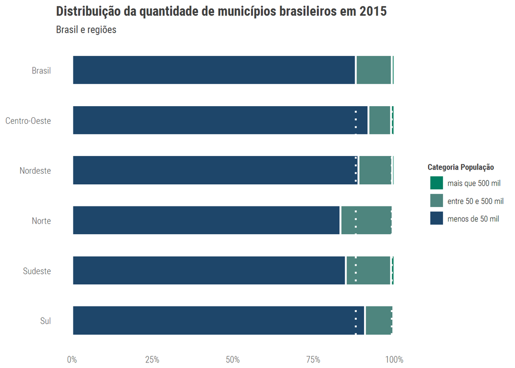

```r
plotSumario_reg_qde
```

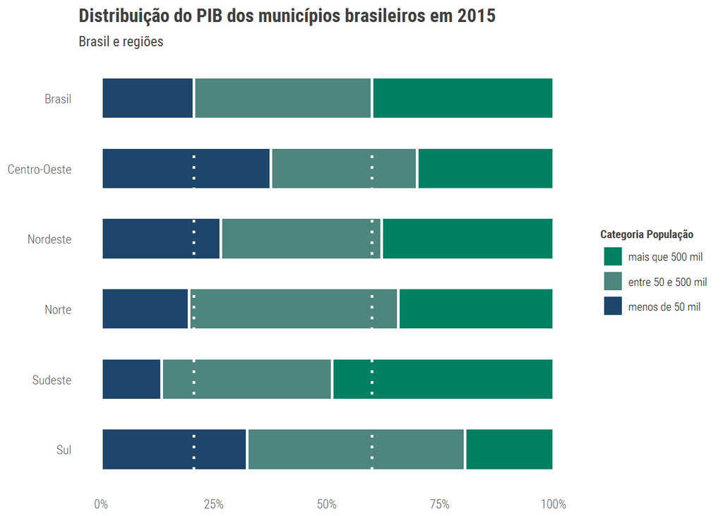

```r
plotSumario_reg_pib
```

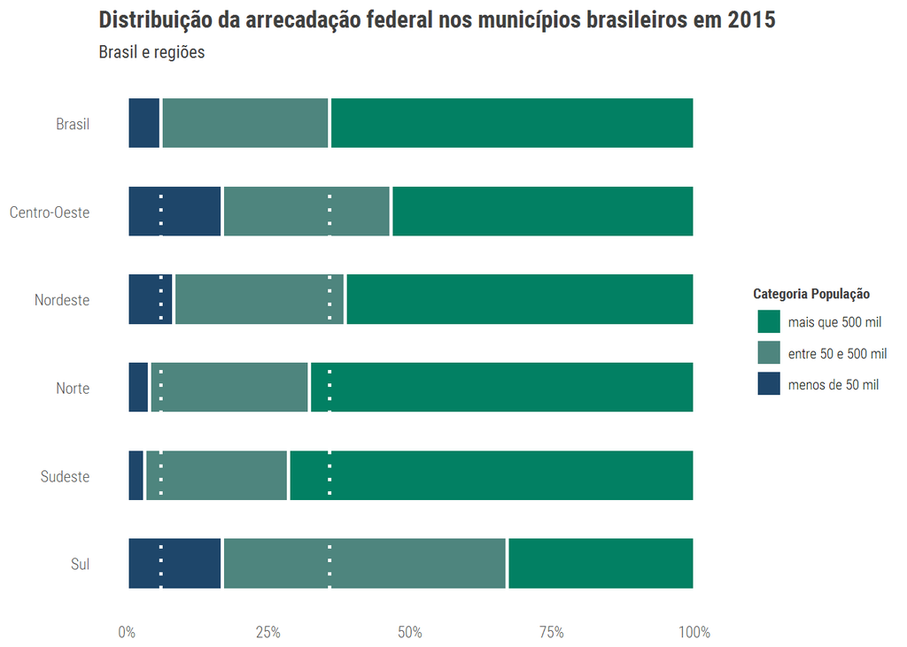

```r
plotSumario_reg_recFed
```

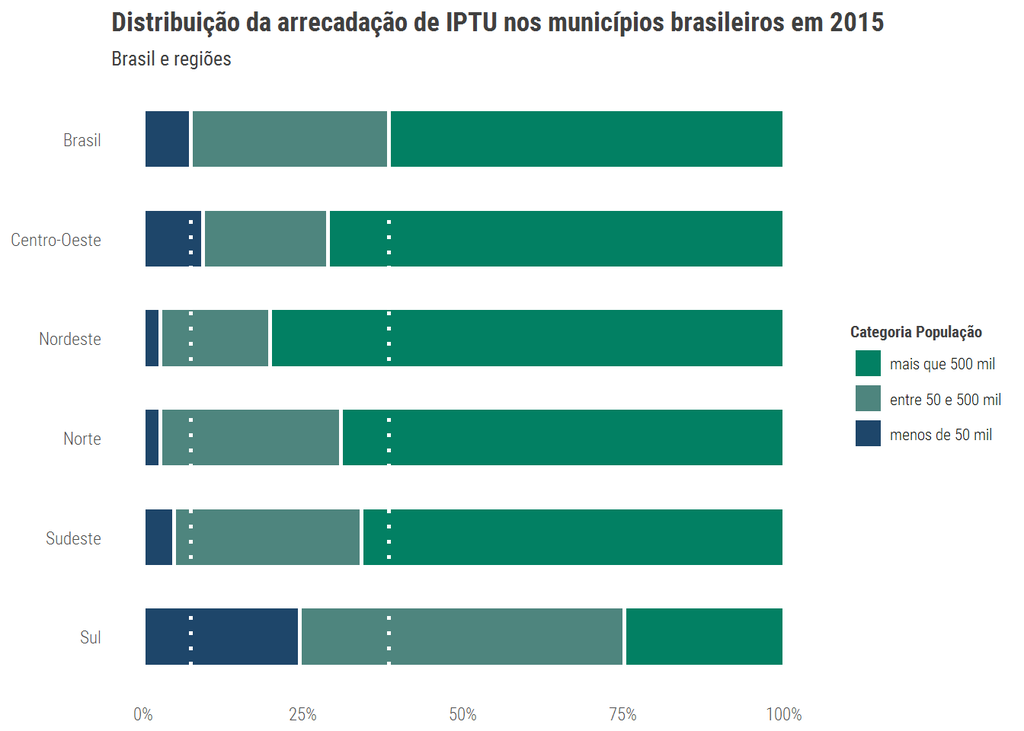

```r
plotSumario_reg_recIPTU
```

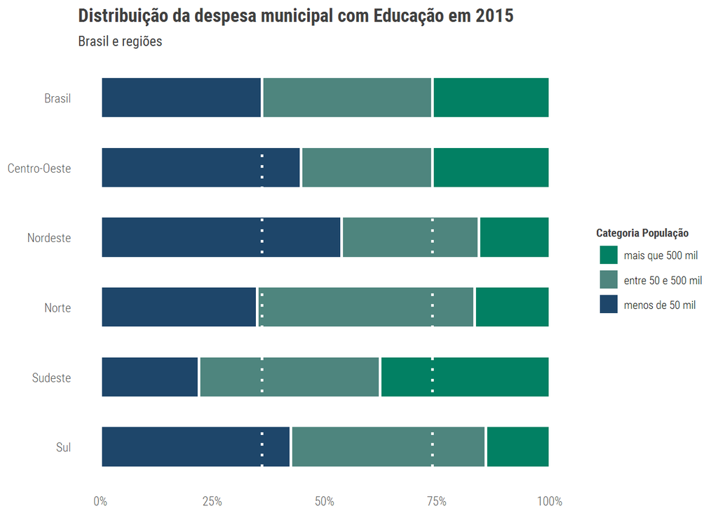

```r
plotSumario_reg_despEduc
```

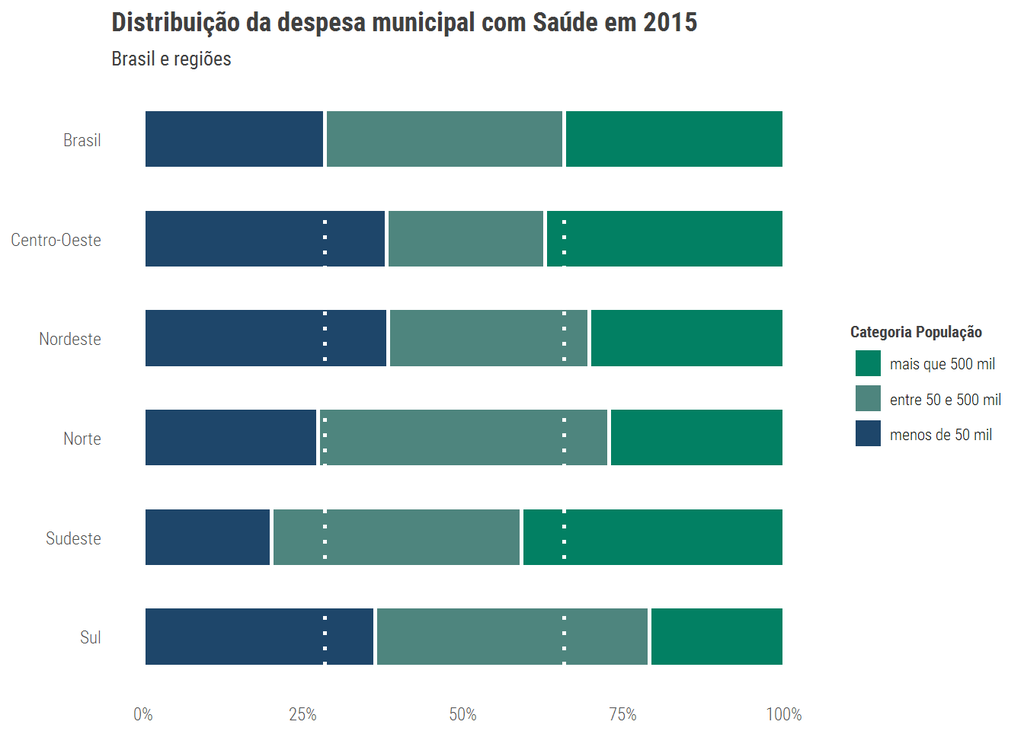

```r
plotSumario_reg_despSaud
```

### Explorando os dados de dependência com gráficos

#### Gráficos de dispersão

Podemos então começar nossa exploração por um gráfico de dispersão, mostrando cada município de nossa base como um ponto, em que a cor indica a região geográfica e o tamanho a população.

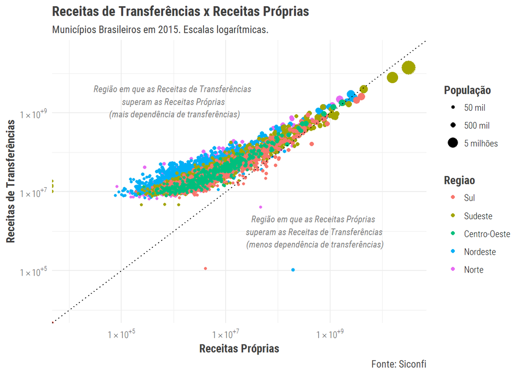

```r
scatter2015 <- ggplot(painel,
                      aes(
                        y = TransfTot,
                        x = RecProp,
                        color = Regiao,
                        size = pop,
                        label = Municipio
                        )
                      )+
  geom_point()+
  scale_x_log10(limits=c(1e+04,3.315440e+10), labels = fancy_scientific)+ #1.100340e+04
  scale_y_log10(limits=c(1e+04,3.315440e+10), labels = fancy_scientific)+ #acrescentar: labels = scales::comma, para não ficar em formato científico
  scale_size(breaks = c(50000,500000,5000000), labels = c("50 mil", "500 mil", "5 milhões"))+
  labs(
    size = "População",
    x = "Receitas Próprias",
    y = "Receitas de Transferências",
    title = "Receitas de Transferências x Receitas Próprias",
    subtitle = "Municípios Brasileiros em 2015. Escalas logarítmicas.",
    caption = "Fonte: Siconfi"
  )+
  geom_abline(intercept = 0, slope = 1, linetype="dotted")+
  annotate(geom="text", x=1e+06, y=2e+09, label="Região em que as Receitas de Transferências \n superam as Receitas Próprias \n (mais dependência de transferências)", color = "grey50", size = 3, fontface = "italic", family = "Roboto Condensed")+ #, family = "Cambria",
  annotate(geom="text", x=5e+08, y=1e+06, label="Região em que as Receitas Próprias \n superam as Receitas de Transferências \n (menos dependência de transferências)", color = "grey50", size = 3, fontface = "italic", family = "Roboto Condensed")

#library(plotly)

#ggplotly(scatter2015 + theme_GTCEAD())

scatter2015+theme_GTCEAD()
```

Observa-se que a grande maioria dos municípios está situada acima da linha de referência, ou seja, na grande maioria dos municípios, as receitas de transferência superam as receitas próprias.

Se refizermos esse gráfico, colorindo desta vez conforme as faixas de dependência de transferências (em que a dependência é definida como a razão entre as receitas de transferências em relação à receita total):

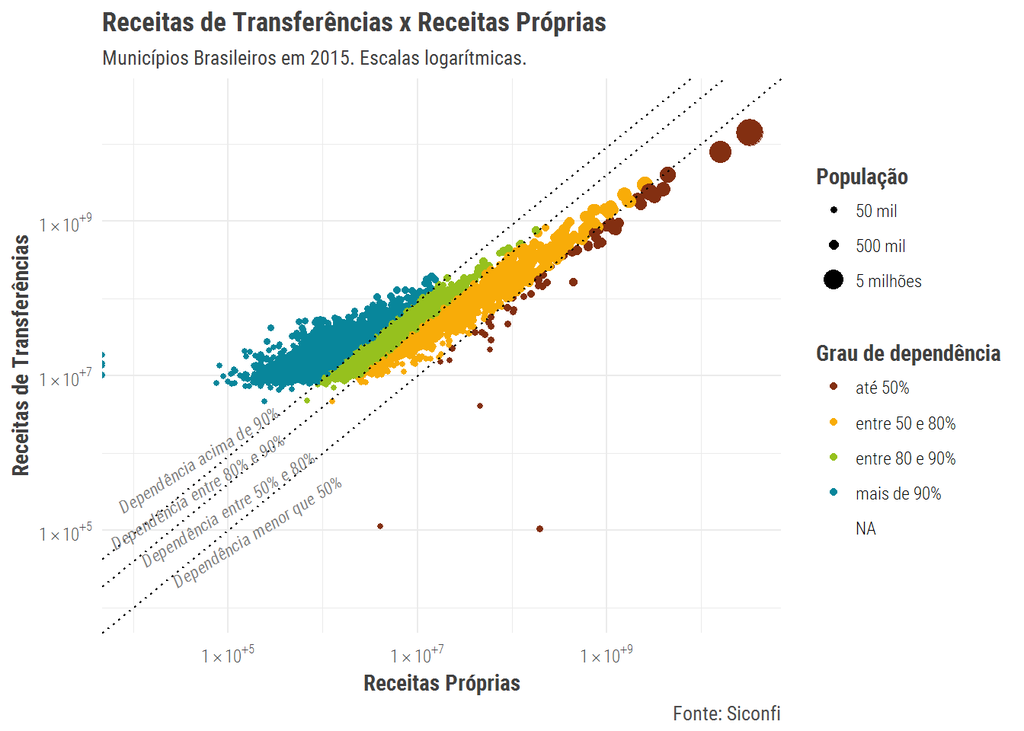

```r
# uma funçaozinha para calculuar a constante de deslocamento da reta que corresponde
# a um determinado índice de dependência.
# GrauDep = RecTransf / RecTot
# mas RecTot = RecTransf + RecProp
# então RecTransf = (GrauDep / (1-GrauDep))*RecProp
# como as escalas são logarítmicas,
# log10(RTr) = log10{(GrauDep / (1-GrauDep))*RecProp}
# log10(RTr) = log10(GrauDep / (1-GrauDep)) + log10(RecProp)
# isso dá um slope de 1, com constante igual a log10(GrauDep/(1-GrauDep))
desloc <- function(GrauDep) {
  log10(GrauDep / (1 - GrauDep))
}

scatter2015_dep <- function(df){
  ggplot(df,
                      aes(
                        y = TransfTot,
                        x = RecProp,
                        color = CatDep,
                        size = pop,
                        label = Municipio
                        )
                      )+
  geom_point()+
  scale_x_log10(limits=c(1e+04,3.315440e+10), labels = fancy_scientific)+ #1.100340e+04
  scale_y_log10(limits=c(1e+04,3.315440e+10), labels = fancy_scientific)+ #acrescentar: labels = scales::comma, para não ficar em formato científico
  scale_size(breaks = c(50000,500000,5000000), labels = c("50 mil", "500 mil", "5 milhões"))+
  labs(
    size = "População",
    x = "Receitas Próprias",
    y = "Receitas de Transferências",
    color = "Grau de dependência",
    title = "Receitas de Transferências x Receitas Próprias",
    subtitle = "Municípios Brasileiros em 2015. Escalas logarítmicas.",
    caption = "Fonte: Siconfi"
  )+
    scale_color_manual(values = c("#832F11","#F8AC08","#96C11E","#08869B"))+
  geom_abline(intercept = 0, slope = 1, linetype="dotted")+
  geom_abline(intercept = desloc(0.80), slope = 1, linetype="dotted")+
  geom_abline(intercept = desloc(0.90), slope = 1, linetype="dotted")+
  annotate(geom="text", x=2e+05, y=1e+05, label="Dependência menor que 50%", color = "grey50", size = 3, fontface = "italic", family = "Roboto Condensed", angle = 32)+
  annotate(geom="text", x=1e+05, y=1.9e+05, label="Dependência entre 50% e 80%", color = "grey50", size = 3, fontface = "italic", family = "Roboto Condensed", angle = 32)+
  annotate(geom="text", x=4.7e+04, y=3.2e+05, label="Dependência entre 80% e 90%", color = "grey50", size = 3, fontface = "italic", family = "Roboto Condensed", angle = 32)+
  annotate(geom="text", x=4.8e+04, y=8.3e+05, label="Dependência acima de 90%", color = "grey50", size = 3, fontface = "italic", family = "Roboto Condensed", angle = 32)+
    theme_GTCEAD()
}
#library(plotly)

#ggplotly(scatter2016 +
#  theme_GTCEAD())

scatter2015_dep(painel)
```

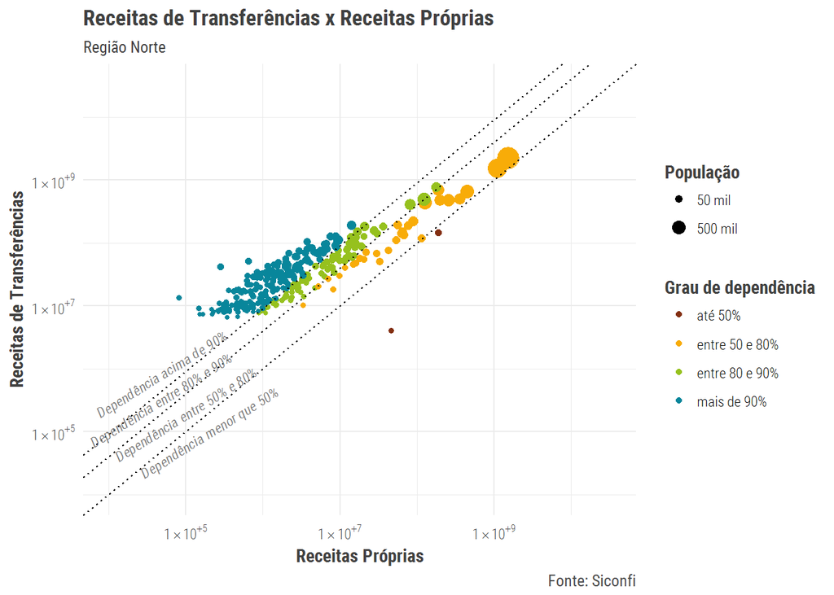

```r
#for (reg in levels(painel$Regiao)) {
#scatter2015_dep(painel%>%filter(Regiao == reg))+labs(subtitle = paste("Região", reg))
#}

scatter2015_dep(painel%>%filter(Regiao == "Norte"))+labs(subtitle = paste("Região", "Norte"))
```

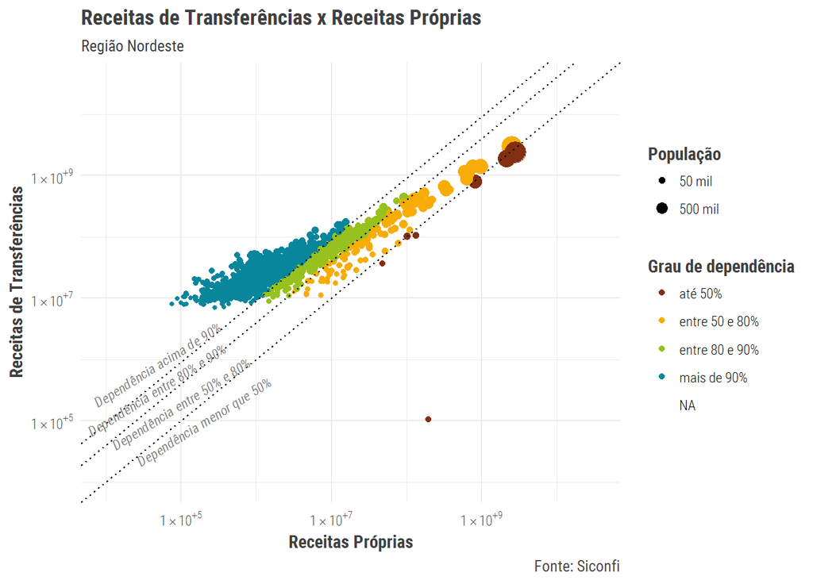

```r
scatter2015_dep(painel%>%filter(Regiao == "Nordeste"))+labs(subtitle = paste("Região", "Nordeste"))
```

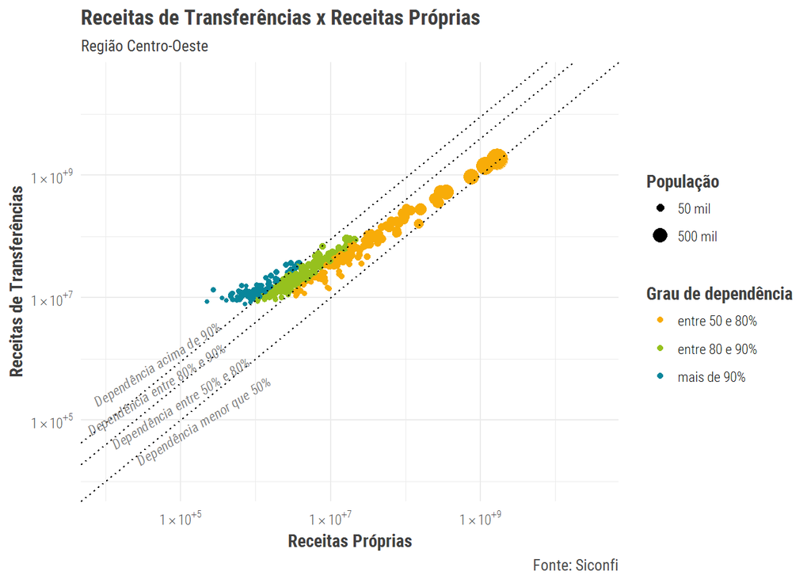

```r
# o centro-oeste não tem municípios com dependência menor que 50%, então o ggplot muda a cor. fixei o vetor de cores na marra só para essa região, mas ficou deselegante.
scatter2015_dep(painel%>%filter(Regiao == "Centro-Oeste"))+labs(subtitle = paste("Região", "Centro-Oeste"))+scale_color_manual(values = c("#F8AC08","#96C11E","#08869B"))
```

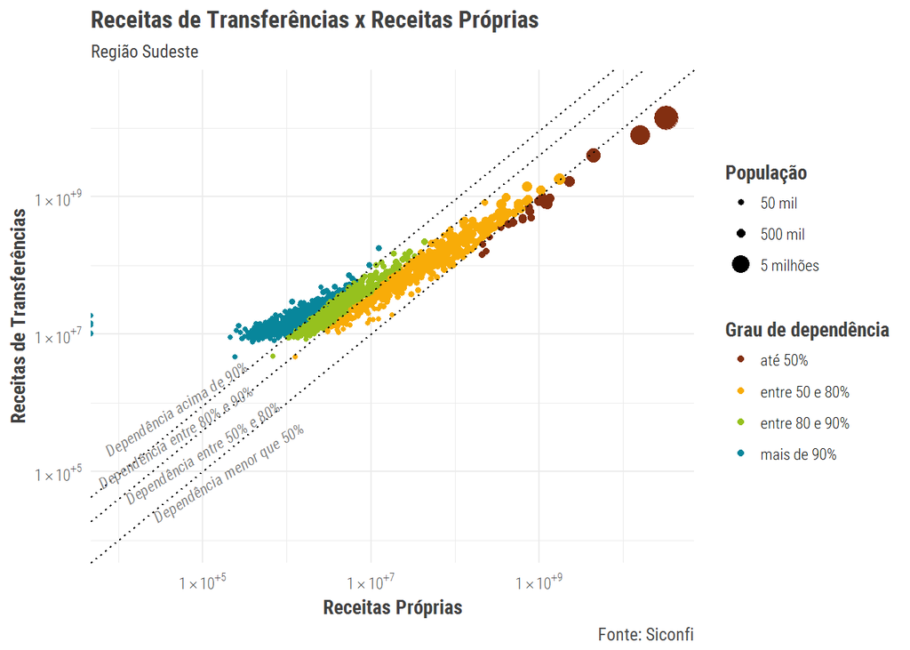

```r
scatter2015_dep(painel%>%filter(Regiao == "Sudeste"))+labs(subtitle = paste("Região", "Sudeste"))
```

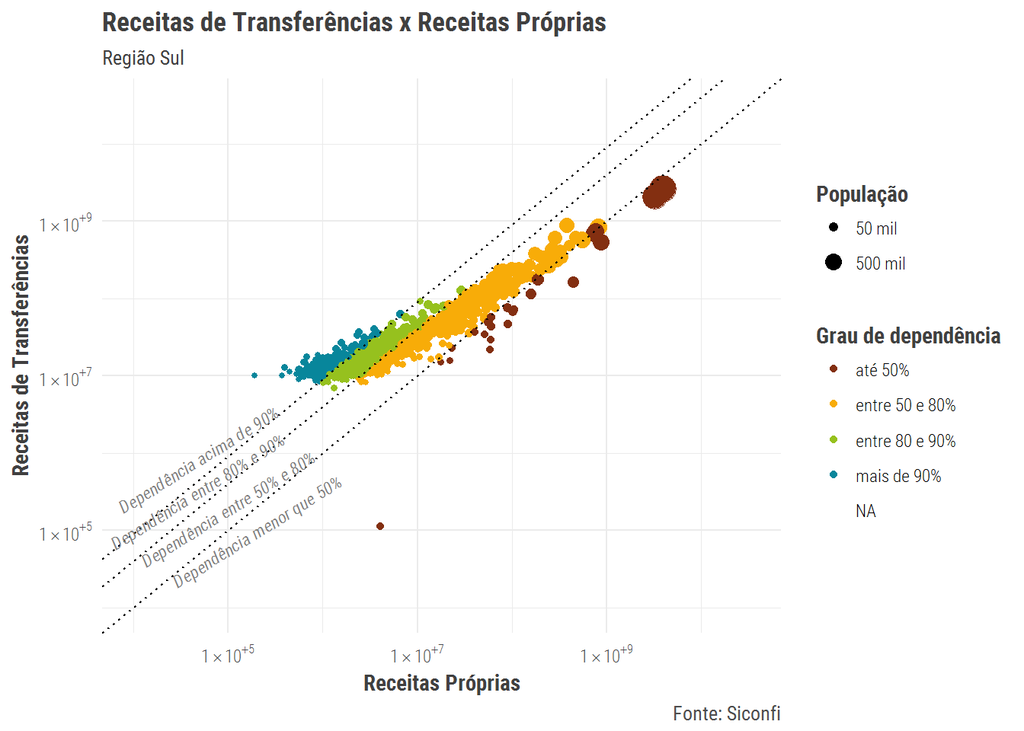

```r
scatter2015_dep(painel%>%filter(Regiao == "Sul"))+labs(subtitle = paste("Região", "Sul"))
```

#### Relação do grau de dependência com as diversas variáveis

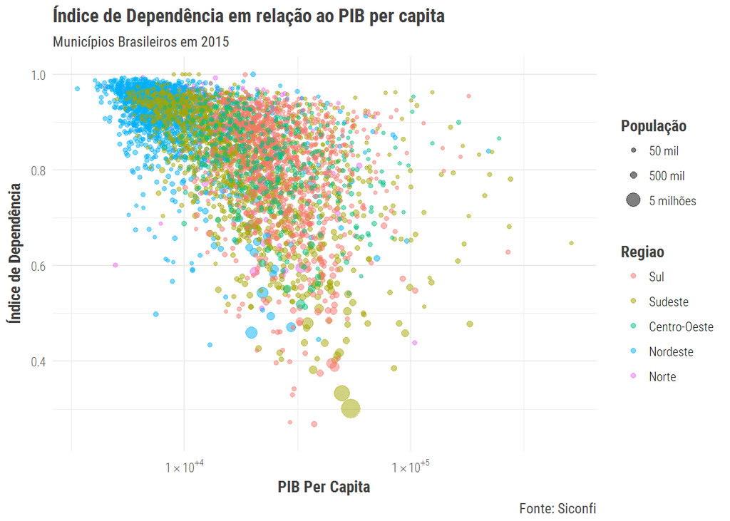

```r
depXpibPcap <- ggplot(painel,
                      aes(
                        y=GrauDep,
                        x=pibPerCapita,
                        color=Regiao,
                        size=pop,
                        label=Municipio
                        )
                      )+
  geom_point(alpha=0.5)+
  scale_x_log10(labels = fancy_scientific)+
  ylim(0.25,1)+
  scale_size(breaks = c(50000,500000,5000000), labels = c("50 mil", "500 mil", "5 milhões"))+
  labs(
    size = "População",
    x = "PIB Per Capita",
    y = "Índice de Dependência",
    title = "Índice de Dependência em relação ao PIB per capita",
    subtitle = "Municípios Brasileiros em 2015",
    caption = "Fonte: Siconfi"
  )+
  theme_GTCEAD()

depXpib <- ggplot(painel,
                      aes(
                        y=GrauDep,
                        x=pib,
                        color=Regiao,
                        size=pop,
                        label=Municipio
                        )
                      )+
  geom_point(alpha=0.5)+
  scale_x_log10(labels = fancy_scientific)+
  ylim(0.25,1)+
  scale_size(breaks = c(50000,500000,5000000), labels = c("50 mil", "500 mil", "5 milhões"))+
  labs(
    size = "População",
    x = "PIB do Município",
    y = "Índice de Dependência",
    title = "Índice de Dependência em relação ao PIB",
    subtitle = "Municípios Brasileiros em 2015",
    caption = "Fonte: Siconfi"
  )+
  theme_GTCEAD()

depXpop <- ggplot(painel,
                      aes(
                        y=GrauDep,
                        x=pop,
                        color=Regiao,
                        size=pib,
                        label=Municipio
                        )
                      )+
  geom_point(alpha=0.5)+
  scale_x_log10(labels = fancy_scientific)+
  ylim(0.25,1)+
  scale_size(breaks = c(10000,1000000,1000000000), labels = c("10 mil", "1 milhão", "1 bilhão"))+
  labs(
    size = "PIB",
    x = "População",
    y = "Índice de Dependência",
    title = "Índice de Dependência em relação à população",
    subtitle = "Municípios Brasileiros em 2015",
    caption = "Fonte: Siconfi"
  )+
  theme_GTCEAD()

depXIPTU <- ggplot(painel,
                      aes(
                        y=GrauDep,
                        x=IPTU,
                        color=Regiao,
                        size=pop,
                        label=Municipio,
                        na.rm = TRUE
                        )
                      )+
  geom_point(alpha=0.5)+
  scale_x_log10(labels = fancy_scientific)+
  ylim(0.25,1)+
  scale_size(breaks = c(50000,500000,5000000), labels = c("50 mil", "500 mil", "5 milhões"))+
  labs(
    size = "População",
    x = "Arrecadação de IPTU",
    y = "Índice de Dependência",
    title = "Índice de Dependência em relação à população",
    subtitle = "Municípios Brasileiros em 2015",
    caption = "Fonte: Siconfi"
  )+
  theme_GTCEAD()

depXdespEduc <- ggplot(painel,
                      aes(
                        y=GrauDep,
                        x=DespEduc,
                        color=Regiao,
                        size=pop,
                        label=Municipio,
                        na.rm = TRUE
                        )
                      )+
  geom_point(alpha=0.5)+
  scale_x_log10(limits = c(1e+06,1e+10), labels = fancy_scientific)+
  ylim(0.25,1)+
  scale_size(breaks = c(50000,500000,5000000), labels = c("50 mil", "500 mil", "5 milhões"))+
  labs(
    size = "População",
    x = "Despesas do município com Educação",
    y = "Índice de Dependência",
    title = "Índice de Dependência em relação à população",
    subtitle = "Municípios Brasileiros em 2015",
    caption = "Fonte: Siconfi"
  )+
  theme_GTCEAD()

depXdespSaude <- ggplot(painel,
                      aes(
                        y=GrauDep,
                        x=DespSaude,
                        color=Regiao,
                        size=pop,
                        label=Municipio,
                        na.rm = TRUE
                        )
                      )+
  geom_point(alpha=0.5)+
  scale_x_log10(limits = c(1e+06,1e+10), labels = fancy_scientific)+
  ylim(0.25,1)+
  scale_size(breaks = c(50000,500000,5000000), labels = c("50 mil", "500 mil", "5 milhões"))+
  labs(
    size = "População",
    x = "Despesas do município com Saúde",
    y = "Índice de Dependência",
    title = "Índice de Dependência em relação à população",
    subtitle = "Municípios Brasileiros em 2015",
    caption = "Fonte: Siconfi"
  )+
  theme_GTCEAD()

depXpibPcap
```

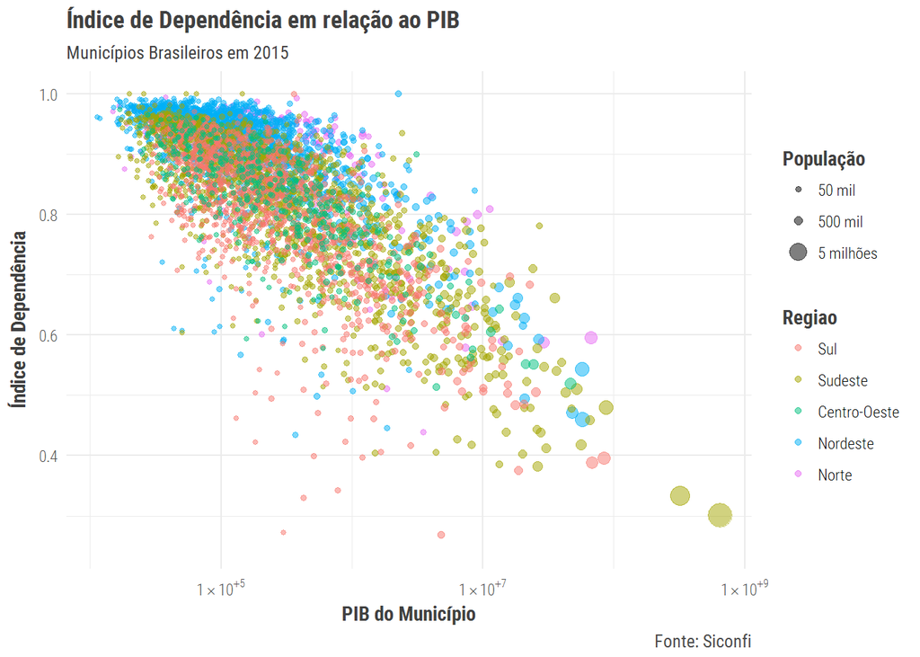

```r
depXpib
```

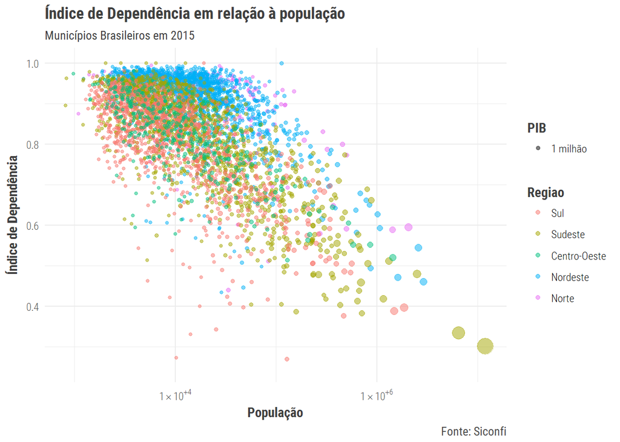

```r
depXpop
```

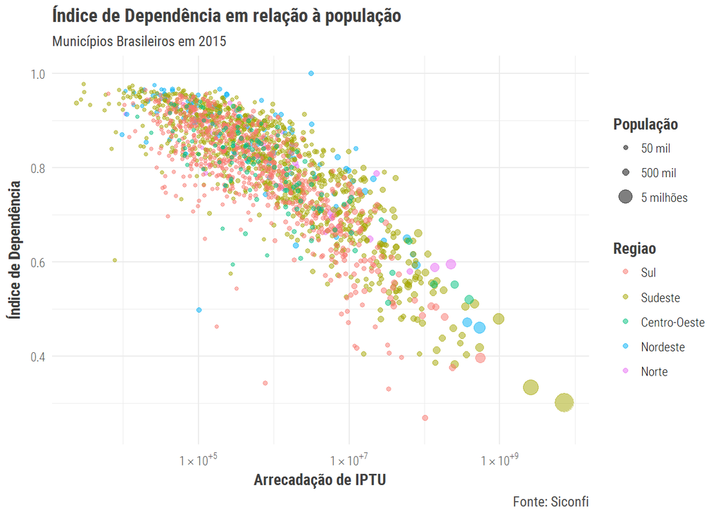

```r
depXIPTU
```

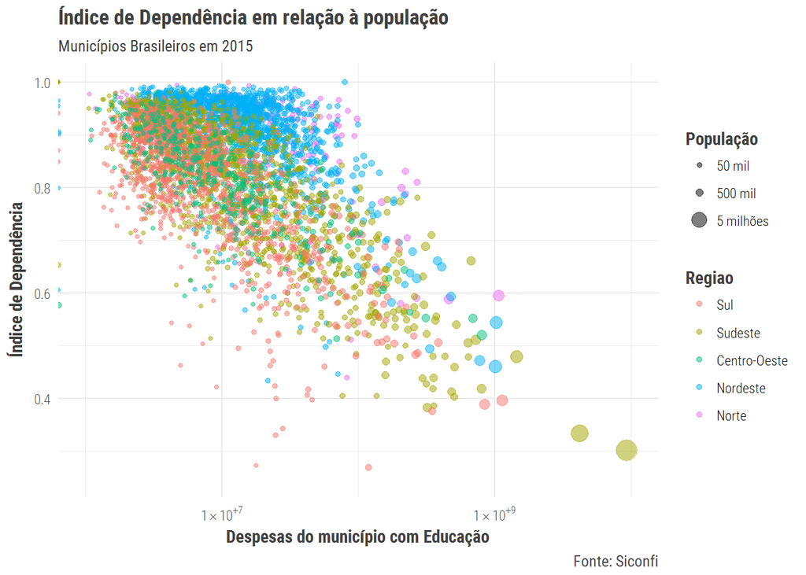

```r
depXdespEduc
```

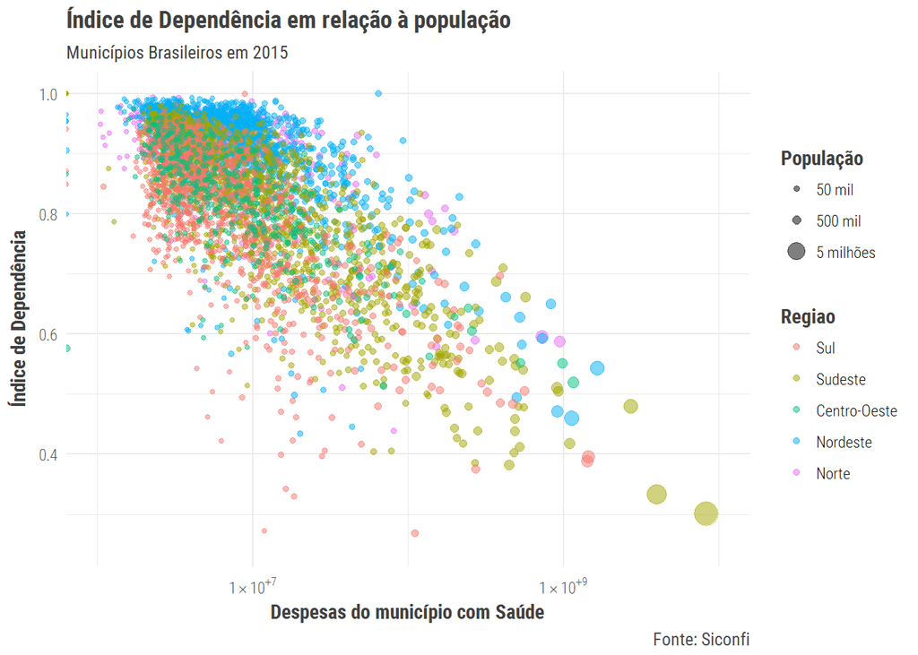

```r
depXdespSaude
```

Continuar:

- fazer um daqueles plots por região. Sumarizar por região, ignorando as categorias de população.
- Mostrar arrecadação de IPTU nas regiões